# How to design efficient fMRI experiments

## 3. Multivariate analysis (MVPA/RSA)

So far we have focused on a single voxel. In multi-voxel pattern analysis (MVPA), or its special case of Representational Similarity Analysis (RSA), we care about how well we can estimate patterns across voxels. Indeed, we normally want to estimate one pattern per trial. As will be shown later, we do not care so much about the absolute Betas in each voxel, but rather about the relative Betas across voxels. Let's assume we have 16 voxels, and two trial-types (A and B), which produce orthogonal patterns over those voxels (but which are randomly intermixed every 2s):

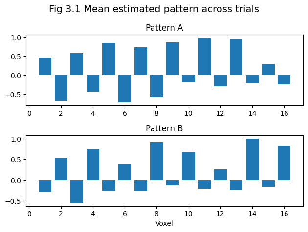

```python
num_vox = 16   # Assume multiple of 2
# Generate orthogonal base patterns:
pat_A = np.tile([1, 0], round(num_vox / 2)).astype(float)
pat_B = np.tile([0, 1], round(num_vox / 2)).astype(float)

num_trl = 160   # (per trial-type)
mB = np.vstack([np.tile(pat_A, (num_trl, 1)), np.tile(pat_B, (num_trl, 1))])

trl_std = 1   # Scaling (std) of trial (co)variability
c_trl = 1     # Covariance across voxels of trial variability (1=all voxels vary same way)
S_trl = c_trl * np.ones((num_vox, num_vox)) + (1 - c_trl) * np.eye(num_vox)   # Covariance matrix for mvnrnd

np.random.seed(1)
# mvnrnd(zeros(size(mB)), S_trl): MATLAB draws one zero-mean sample per row of mB,
# all with covariance S_trl -- replicated here as additive noise with size=mB.shape[0]
B = mB + trl_std * np.random.multivariate_normal(np.zeros(num_vox), S_trl, size=mB.shape[0])

r = np.random.permutation(2 * num_trl) + 1   # ...then permute their order randomly
# r = np.arange(1, 2*num_trl + 1)
mB = mB[r - 1, :]
B = B[r - 1, :]
v = np.floor((r - 1) / num_trl).astype(int) + 1   # (ordered labels for each stimulus-type)

# Generate LSA design matrix based on trial orders
TR = 1
SOA = 2
X_LSA, K, KX = gen_X(np.arange(1, 2 * num_trl + 1), SOA, HRF, TR)
X_LSA = np.hstack([X_LSA, np.ones((X_LSA.shape[0], 1))])
pX_LSA = np.linalg.pinv(X_LSA)

# Now generate data (similar to code above)
dt = 0.1
num_smp = int(2 * num_trl * SOA / dt)
u = np.zeros((num_smp, num_vox))
u[0:num_smp:int(SOA / dt), :] = B

s = lconv(u, HRF[:, np.newaxis])
TR_bins = round(TR / dt)
s = s[round(TR_bins / 2)::TR_bins, :]   # downsample each TR (at middle of TR, matching gen_X's convention)
num_TRs = s.shape[0]

scn_std = 1     # Scaling (std) of noise (co)variability (trl_std/scn_std = SNR)
c_scn = 0.75    # Covariance across voxels of scan variability (noise)
S_scn = c_scn * np.ones((num_vox, num_vox)) + (1 - c_scn) * np.eye(num_vox)

y = s + scn_std * np.random.multivariate_normal(np.zeros(num_vox), S_scn, size=num_TRs)   # Add zero-mean multivariate Gaussian noise

B_hat = pX_LSA @ y   # (Note GLM OLS still works if y is matrix, ie fits all voxels simultaneously)
B_hat = B_hat[:-1, :]   # Ignore constant term

labels = ['A', 'B']
B_con = {}
mB_hat = np.full((2, num_vox), np.nan)
fig, axes = plt.subplots(2, 1)
fig.suptitle('Fig 3.1 Mean estimated pattern across trials', fontsize=14)
for c in [1, 2]:
    B_con[c] = B_hat[v == c, :]
    mB_hat[c - 1, :] = np.mean(B_con[c], axis=0)
    ax = axes[c - 1]
    ax.bar(np.arange(1, num_vox + 1), mB_hat[c - 1, :])
    ax.set_title(f'Pattern {labels[c - 1]}')
    if c == 2:
        ax.set_xlabel('Voxel')

plt.tight_layout()
plt.show()
```

```python
print(f'Correlation between true (generating) patterns = {np.corrcoef(pat_A, pat_B)[0,1]:.2f}')
```

```
Correlation between true (generating) patterns = -1.00
```

```python
print(f'Correlation between mean estimated patterns = {np.corrcoef(mB_hat[0, :], mB_hat[1, :])[0, 1]:.2f}')
```

```
Correlation between mean estimated patterns = -0.83
```

Fig 3.1 shows the two estimated patterns across voxels after averaging across trials, which reasonably well reproduce the true patterns (which are alternating 1s and 0s that just in anti-phase for the two patterns, as indicated by the negative correlations between them).

### 3.1 Within-Between Similarity

For MVPA, we want to classify each single trial as an A or a B. There are many different types of machine-learning algorithms that do this, but assuming they use a correlational measure of similarity, their performance ultimately depends on the correlation between trials of the same type, relative to the correlation between trials of different types - the "within - between similarity" (W-B). In this case, more efficient MVPA designs maximise this difference metric, which is calculated by the function "wbc" below, and which we can plot as a function of the covariance of trial and scan variability across voxels (may take a while...):

```python
trl_std = 0.5   # Scaling (std) of trial (co)variability
scn_std = 0.5   # Scaling (std) of noise (co)variability (trl_std/scn_std = SNR)

c_trl = [1, 1, 0, 0]
c_scn = [1, 0, 1, 0]

transient = int(np.ceil(32 / SOA))   # Must be less than half num_trl!
sv = v[transient:len(v) - transient]

# For L2-regularised LSA
lam = 1   # regularisation hyper-parameter (lambda is a reserved keyword in Python)
Rmat = np.block([[np.eye(2*num_trl), np.zeros((2*num_trl, 1))],
                 [np.zeros((1, 2*num_trl)), 0]])    # regularise all Betas but not grand mean
pX_LSA_reg = np.linalg.inv(X_LSA.T @ X_LSA + lam * Rmat) @ X_LSA.T   # Ridge regression or L2-norm regularisation

num_cov = len(c_trl)
est_wbc = np.full((num_exp, 3, num_cov), np.nan)
for s in range(num_cov):
    print(f'Computing with c_trl = {c_trl[s]} and c_scn = {c_scn[s]}...')
    for e in range(num_exp):
        y, _ = gen_y(mB, SOA, trl_std, scn_std, HRF, TR, c_trl[s], c_scn[s])

        B_hat_LSA = pX_LSA @ y
        B_hat_LSA = B_hat_LSA[transient:len(B_hat_LSA) - transient - 1, :]   # remove transients and constant term
        B_con = {c: B_hat_LSA[sv == c, :] for c in [1, 2]}   # reassign trial number to condition
        est_wbc[e, 0, s] = wbc(B_con)

        B_hat_LSS, sv2 = fit_lss(X_LSA, v, y, transient)   # sv is v without transients
        B_con = {c: B_hat_LSS[sv == c, :] for c in [1, 2]}   # reassign trial number to condition
        est_wbc[e, 1, s] = wbc(B_con)

        B_hat_LSA_reg = pX_LSA_reg @ y
        B_hat_LSA_reg = B_hat_LSA_reg[transient:len(B_hat_LSA_reg) - transient - 1, :]   # remove transients and constant term
        B_con = {c: B_hat_LSA_reg[sv == c, :] for c in [1, 2]}   # reassign trial number to condition
        est_wbc[e, 2, s] = wbc(B_con)
```

```
Computing with c_trl = 1 and c_scn = 1...
Computing with c_trl = 1 and c_scn = 0...
Computing with c_trl = 0 and c_scn = 1...
Computing with c_trl = 0 and c_scn = 0...
```

```
c_trl = 1 and c_scn = 1...
	 LSA:     W-B=2.00 (Z=4445374918675825.00)
	 LSS:     W-B=2.00 (Z=8754374222219099.00)
	 LSA-reg:     W-B=1.06 (Z=242373284107963.75)
c_trl = 1 and c_scn = 0...
	 LSA:     W-B=0.20 (Z=11.05)
	 LSS:     W-B=1.57 (Z=63.04)
	 LSA-reg:     W-B=0.91 (Z=47.19)
c_trl = 0 and c_scn = 1...
	 LSA:     W-B=1.04 (Z=53.33)
	 LSS:     W-B=0.55 (Z=18.77)
	 LSA-reg:     W-B=0.62 (Z=36.98)
c_trl = 0 and c_scn = 0...
	 LSA:     W-B=0.18 (Z=10.76)
	 LSS:     W-B=0.51 (Z=19.37)
	 LSA-reg:     W-B=0.55 (Z=34.20)
```

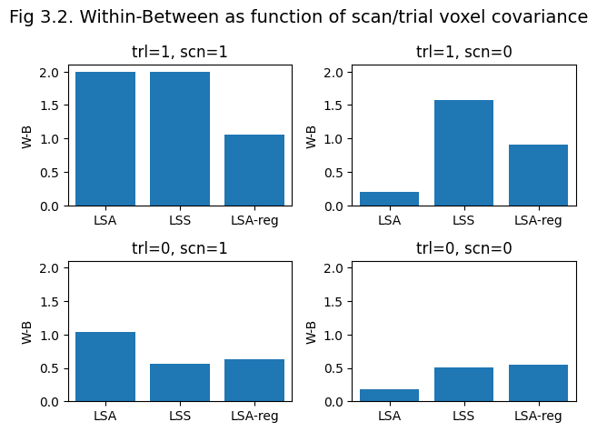

```python
fig, axes = plt.subplots(2, 2)
fig.suptitle('Fig 3.2. Within-Between as function of scan/trial voxel covariance', fontsize=14)
axes = axes.flatten()

np.random.seed(1)
for s in range(num_cov):
    print(f'c_trl = {c_trl[s]} and c_scn = {c_scn[s]}...')
    p = []
    for method, label in enumerate(['LSA', 'LSS', 'LSA-reg']):
        m = np.mean(est_wbc[:, method, s])
        d = np.std(est_wbc[:, method, s])
        print(f'\t {label}:     W-B={m:.2f} (Z={m/d:.2f})')
        p.append(m)

    ax = axes[s]
    ax.bar(np.arange(3), p)
    ax.set_xticks(np.arange(3))
    ax.set_xticklabels(['LSA', 'LSS', 'LSA-reg'])
    ax.set_ylim([0, 2.1])
    ax.set_xlim([-0.5, 2.5])
    ax.set_title(f'trl={c_trl[s]}, scn={c_scn[s]}')
    ax.set_ylabel('W-B')

plt.tight_layout()
plt.show()
```

The top left plot of Fig 3.2 shows that when trial and scan variability covary perfectly across voxels (ie, same amount added to every voxel), the W-B value is 2 for LSA and LSS, as expected (since correlation within pattern A or B is 1, and between A and B is -1, so their difference is 2). With LSA-reg, the W-B is less because of shrinkage of the estimates. When the scan noise is independent across voxels (top right), then LSS does better than LSA (and LSA-reg is intermediate). On the other hand, when trial variability is independent across voxels but scan noise is perfectly correlated across voxels (bottom left), then LSA does better than LSS (and LSA-reg). The bottom right shows the case of independent variability across voxels for both trial and scan variability, where LSS (and LSA-reg) happen to do better, though which estimator does better in general will depend on the ratio of the total variability (ie, of trl_std:scn_std, as demonstrated in the Section 2.3 (temporal smoothness regularisation)) - a ratio that just happens to be 1 in the above example - as well as depending on lambda in the case of LSA-reg).

To understand why the covariance of trial and scan variability across voxels matters for the W-B measure, and MVPA classification more generally, let's plot just the first 16 trials of each condition (first 16 Beta estimates for condition A followed by first 16 Beta estimates for condition B), averaged across all odd and all even voxels (since patterns A and B differ in the odd/even ordering of 1s and 0s across voxels). This is shown in Fig 3.3 below for LSA and in Fig 3.4 for LSS:

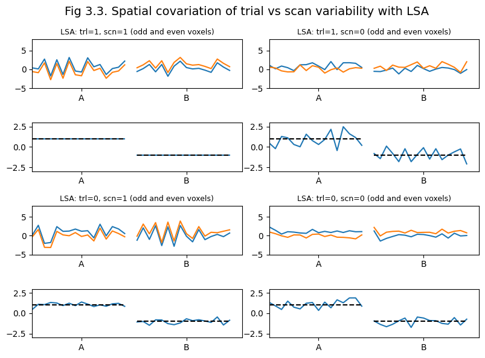

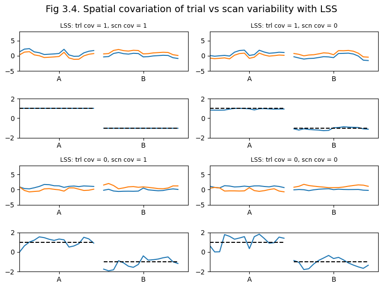

```python
sp1 = [1, 2, 5, 6]   # time-series subplots
sp2 = [3, 4, 7, 8]   # difference subplots

f1, axes1 = plt.subplots(4, 2, figsize=(8, 6))
f1.suptitle('Fig 3.3. Spatial covariation of trial vs scan variability with LSA', fontsize=14)
f2, axes2 = plt.subplots(4, 2, figsize=(8, 6))
f2.suptitle('Fig 3.4. Spatial covariation of trial vs scan variability with LSS', fontsize=14)

show_trl = np.arange(16)   # Subset of trials of each condition to show (0-based: 0:16)
# Reference line for difference plots: +1 for condition A, NaN gap, -1 for condition B
diff_ref = np.concatenate([np.ones(len(show_trl)), [np.nan], -np.ones(len(show_trl))])

np.random.seed(1)
for s in range(num_cov):
    y, _ = gen_y(mB, SOA, trl_std, scn_std, HRF, TR, c_trl[s], c_scn[s])

    B_hat_LSA = pX_LSA @ y
    B_hat_LSA = B_hat_LSA[transient:len(B_hat_LSA) - transient - 1, :]   # remove transients and constant term

    B_con = {}
    for c in [1, 2]:
        Bc = B_hat_LSA[sv == c, :]
        B_con[c] = np.column_stack([
            np.mean(Bc[show_trl, 0::2], axis=1),   # average over odd voxels (0-based: 0,2,4...)
            np.mean(Bc[show_trl, 1::2], axis=1)    # average over even voxels (0-based: 1,3,5...)
        ])
    mB_hat = np.vstack([B_con[1], np.full((1, 2), np.nan), B_con[2]])   # NaN gap between conditions

    r1, c1 = (s // 2) * 2, s % 2      # timeseries: rows 0,0,2,2 and cols 0,1,0,1
    r2, c2 = (s // 2) * 2 + 1, s % 2  # difference: rows 1,1,3,3 and cols 0,1,0,1

    ax = axes1[r1, c1]
    ax.plot(mB_hat)
    ax.axis([0, 34, -5, 8])
    ax.set_xticks([8, 25])
    ax.set_xticklabels(['A', 'B'])
    ax.set_title(f'LSA: trl={c_trl[s]}, scn={c_scn[s]} (odd and even voxels)', fontsize=9)

    ax = axes1[r2, c2]
    ax.plot(mB_hat[:, 0] - mB_hat[:, 1])
    ax.axis([0, 34, -3, 3])
    ax.set_xticks([8, 25])
    ax.set_xticklabels(['A', 'B'])
    ax.plot(diff_ref, 'k--')

    B_hat_LSS, sv2 = fit_lss(X_LSA, v, y, transient)

    for c in [1, 2]:
        Bc = B_hat_LSS[sv == c, :]
        B_con[c] = np.column_stack([
            np.mean(Bc[show_trl, 0::2], axis=1),   # average over odd voxels
            np.mean(Bc[show_trl, 1::2], axis=1)    # average over even voxels
        ])
    mB_hat = np.vstack([B_con[1], np.full((1, 2), np.nan), B_con[2]])   # NaN gap between conditions

    ax = axes2[r1, c1]
    ax.plot(mB_hat)
    ax.axis([0, 34, -5, 8])
    ax.set_xticks([8, 25])
    ax.set_xticklabels(['A', 'B'])
    ax.set_title(f'LSS: trl cov = {c_trl[s]}, scn cov = {c_scn[s]}', fontsize=9)

    ax = axes2[r2, c2]
    ax.plot(mB_hat[:, 0] - mB_hat[:, 1])
    ax.axis([0, 34, -2, 2])
    ax.set_xticks([8, 25])
    ax.set_xticklabels(['A', 'B'])
    ax.plot(diff_ref, 'k--')

f1.tight_layout()
f2.tight_layout()
plt.show()
```

Fig 3.3 and Fig 3.4 have the same 2x2 layout of the 4 cases as in Fig 3.2 (i.e., from perfect covariance across voxels for both trials and scans in top left, to total independence in bottom right). Within each one of the 4 cells there is a top and bottom plot. The top plot shows odd and even voxels separately (in orange and blue); the bottom plot shows their difference (in blue), along with black dashed lines for the mean pattern values. The difference between odd and even voxels is a measure of the pattern difference. The key idea is that better classification performance is achieved when the A and B conditions can be better distinguished in terms of their odd-even voxel difference, ie the variability across trials of this difference is small within a condition, relative to the mean difference between conditions (ie, 2). In other words, what matters for pattern classification is not the overall scaling across all voxels, but the relative difference between voxels.

For LSA (Fig 3.3), when the scan noise is identical across voxels (bottom left cell), while the Beta estimates vary considerably across trials for both orange (even) and blue (odd) voxels, they vary in the same way, so that the difference between orange and blue in the plot below does not vary much between trials of the same type, so that the mean difference between A and B trial types is large relative to the variance within types. This means A and B will be well classified. For the two cells on the right, when scan noise is independent across voxels, the orange and blue voxels vary differently, so their difference varies a lot within trials of the same type, which will reduce the ability to classify trials as A or B.

Thus in summary, whether LSS or LSA is a better estimator for MVPA depends on not just the ratio of trial variance to scan variance, but also the relative degree of covariance across voxels of trial variability and scan variability. While we may not always know or be able to measure these ratios independently, there might be a priori reason to suspect whether each ratio is bigger or smaller than one.

**Finally, note that the presence of spatially-correlated noise every TR is likely to be the main reason why MVPA has been performed successfully even with short SOAs of a few seconds: even though estimating the mean across voxels for individual trials at such short SOAs is very inefficient (Section 1.1), one can still estimate relative differences across voxels (i.e, patterns) well.**

## Common Questions

Below are a collection of various related questions that are often raised.

### I. What is the minimum number of events I need?

Unfortunately, there is no answer to this, other than "the more, the better". The statistical power depends on the effect size and variability, and this is normally unknown. People who say "you cannot do an event-related fMRI analysis with less than N events" are talking rubbish, unless they have a specific effect size in mind (which is a function of the experimental effect, the brain region, the scanner strength, the sequence optimization, etc, etc...). Note it is even possible that fewer trials are required (for a given power) than for an equivalent contrast of behavioural data (the noise in, e.g, response times (RTs) may exceed that of the BIR in a specific cortical region contributing to those RTs). Furthermore, it is not even the number of events per se that is relevant: it is also the SOA and event-ordering (as demonstrated above).

### II. Doesn't shorter SOAs mean more power simply because of more trials?

It is not simply the number of trials: the temporal distribution of those trials is vital (as explained above). Thus 400 stimuli every 3s is LESS efficient than 40 stimuli every 30s for detecting a single event-related response versus interstimulus baseline (since a fixed SOA of 3s produces little experimental variability after convolution by the BIR). Indeed, 200 stimuli occurring with a 50% probably every 3s (i.e, pseudorandomly mixed with 200 null events) is much more efficient than either, though note again, if you have a limited number of trials (eg, stimuli), but plenty of scan time, long SOAs can be more efficient than short SOAs simply by virtue of allowing more volumes to be acquired in total (ie longer experiment, ie more df's). The efficiency arguments above are predicted on having a fixed scan time, over which an effectively unlimited number of trials can be distributed (eg, a sufficiently large stimulus set).

### III. What is the maximum number of conditions I can have?

A common interpretation of the general advice above - not to contrast trials that are too far apart in time - is not to design experiments with too many experimental conditions. More conditions necessarily mean that replications of a particular condition will be further apart in time. However, the critical factor is not the number of conditions per se, but the specific contrasts performed over those conditions. For pairwise comparisons of only 2 of, say, 8 blocked conditions (e.g, a [1 -1 0 0 0 0 0 0] contrast), the above caveat would apply: if there were equal numbers of blocks of each condition, blocks longer than 12.5s (100s/8) are likely to entail a substantial loss of signal when using a highpass cutoff of 0.01Hz. However, this caveat would not apply if the contrasts of interest included ("spanned") all 8 conditions, as would be the case if the experimenter were only interested in the two main effects and the interaction within a 2x4 factorial design (i.e, contrasts like [1 1 1 1 -1 -1 -1 -1] ). If you must compare only a subset of many such blocked conditions, you should consider presenting those blocks in a fixed order, rather than random or counter-balanced order, which will minimise the time between replications of each condition, i.e, maximise the frequency of the contrast (as always, assuming no psychological caveats with a non-random ordering of conditions).

### IV. Should I use null events?

Null events are simply a convenient means of achieving a stochastic distribution of SOAs, in order to allow estimation of the response vs. interstimulus baseline, by randomly intermixing them with the events of interest. However, the "baseline" may not always be meaningful. It may be well-defined for V1, in terms of visual flashs versus a dark background. It becomes less well-defined for "higher" regions associated with cognition however, because it is often unclear what these regions are "doing" during the interstimulus interval. The experimenter normally has little control over this. Also note that the baseline is only as good as it controls for aspects of the events of interest (e.g, a fixation cross hair does not control for visual size when used as a baseline for words). Moreover, it does not control for the fact that the events are impulsive (rapid changes) whereas the baseline is sustained (and may entail, e.g, adaptation or reduced attention). For this reason, it is often better to forget about baseline and add an extra low-level control event instead.

Another problem with null events is that, if they are too rare (e.g, less than approx 33%), they actually become "true" events in the sense that participants may be expecting an event at the next SOAmin and so be surprised when it does not occur (the so-called "missing stimulus" or "omission" effect that is well-known in ERP research). One solution is to replace randomly intermixed null events with periods of baseline between blocks of events. This will increase the efficiency for detecting the common effect vs. baseline, at a slight cost in efficiency for detecting differences between the randomised event-types within each block.

Yet another problem is that sometimes the unpredictability of the occurrence of true events (caused by the randomly intermixed null events) can cause delayed or even missed processing of the events of interest. If participants must respond quickly to each event, for example, it is often advantageous if they know roughly when each event will occur, and so prepare for it.

So to answer the question, null events are probably only worthwhile if 1) you think the mean activity during the constant interstimulus interval is meaningful to contrast against, 2) you don't mind null events being reasonably frequent (to avoid "missing stimulus" effects) and 3) you don't mind the stimulus occurrence being unpredictable (as far as the participant is concerned). Having said this, some form of baseline can often serve as a useful "safety net" (e.g, if you fail to detect differences between two visual event-types of interest, you can at least examine V1 responses and check that you are seeing a basic evoked response to both event-types; if not, you can question the quality of your data or accuracy of your model). But then again, that baseline might be better estimated from "blocked" periods of baseline, rather than randomly intermixed null events.

Remember that randomly intermixed null events are not NECESSARY to analyse event-related responses if you have a rough idea what form the BOLD impulse response takes. If however you do want to estimate the precise shape of the BIR, then they do become necessary, as detailed in the Section on Detection Power vs Estimation Efficiency.

### V. Should I generate multiple random designs and choose the most efficient one?

This is certainly possible, though be wary that such designs are likely to converge on designs with some structure (e.g, blocked designs, given that they tend to be optimal, as explained above). This may be problematic if such structure affects participants' behaviour (particularly if they notice the structure). Note however that there are software tools available that optimise designs at the same time as allowing users to specify a certain level of counterbalancing (to avoid fully blocked designs): e.g, [Wager & Nichols, 2003], or the "OptSeq" program developed by Doug Greve.

### VI. Should I treat my trials as events or epochs?

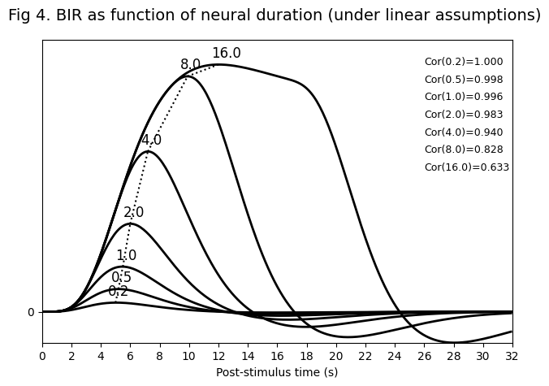

```python
dt = 0.1
HRF = canonical_HRF(dt)
pst = dt * np.arange(1, len(HRF) + 1) - dt
z = np.zeros_like(pst)

durations = [0.2, 0.5, 1, 2, 4, 8, 16]

fig, ax = plt.subplots()
fig.suptitle('Fig 4. BIR as function of neural duration (under linear assumptions)', fontsize=14)

BIRs = np.full((len(pst), len(durations)), np.nan)
m = np.full(len(durations), np.nan)
t = np.full(len(durations), np.nan)
c = np.ones(len(durations))

for d, dur in enumerate(durations):
    u = z.copy()
    u[:round(dur / dt)] = dt
    BIRs[:, d] = lconv(u[:, np.newaxis], HRF[:, np.newaxis])[:, 0]
    # plot(pst, u, 'LineWidth', 1, 'Color', 'k')  # commented out as in original
    ax.plot(pst, BIRs[:, d], linewidth=2, color='k')
    peak_idx = np.argmax(BIRs[:, d])
    m[d] = BIRs[peak_idx, d]
    t[d] = pst[peak_idx]
    ax.text(t[d] - 0.5, m[d] + 0.16, f'{dur:2.1f}', fontsize=12)
    if d > 0:
        ax.plot([t[d-1], t[d]], [m[d-1], m[d]], 'k:')
        c[d] = np.corrcoef(BIRs[:, d], BIRs[:, d-1])[0, 1]

ax.axis([0, np.max(pst), np.min(BIRs), 1.1 * np.max(BIRs)])
xticks = np.arange(0, np.max(pst) + 1, 2, dtype=int)
ax.set(yticks=[0], xticks=xticks, xticklabels=xticks, xlabel='Post-stimulus time (s)')

# Show correlations
for d, dur in enumerate(durations):
    ax.text(26, (1 - d / (2 * len(durations))) * np.max(BIRs),
            f'Cor({dur:2.1f})={c[d]:4.3f}', fontsize=9)

plt.tight_layout()
plt.show()
```

For longer duration trials, the response begins to plateau, meaning that an "epoch model" can be a better model. More important however, is the case of trials that vary in duration from trial to trial within a condition, or across conditions. To appreciate this, consider trials consisting of a stimulus followed by a response. Whether these trials are better modelled as events, or as epochs of different durations (e.g, with duration equal to the RT for each trial), is debatable. For example, if the stimulus duration were constant and only RTs varied, then the activity in V1 may not be expected to vary with RT, so an "event model" might fit better (and in this case, the parameter estimate can be interpreted as the BOLD response ''per trial''). For activity in premotor cortex on the other hand, greater activity might be expected for trials with longer RTs, so a "varying-epoch model" might fit better (and in this case, the parameter estimate can be interpreted as the BOLD response ''per unit time''). So the answer depends on your assumptions about the duration of neural activity in the particular brain regions of interest (and one solution can be to model each trial as both a delta function at trial onset AND an epoch of trial duration, assuming the range of trial durations is sufficient to decorrelate the resulting regressors to some extent; see also [Mumford et al. (2023)](https://doi.org/10.1038/s41562-023-01760-0)).

## Glossary

Here are the meanings of the most common variables used in code above:

u = neural timeseries (every dt) of assumed neural activity (e.g., delta function every SOA)

v = vector of trial-types every SOAmin (e.g., 12--2-1--112), regardless of their timing

y = fMRI timeseries, ie BOLD response every TR (possibly with noise added)

X = design matrix (TRs by regressors/predictors)

pX = pseudo-inverse of X (for OLS estimation)

B = parameter of X (one per column of X)

B_hat = estimated parameter value

c = contrast (vector for T-contrast; matrix for F-contrast)